# R03

## Week 3

The goal of this week's assignment is to express each of the following signals as sums of sines and cosines. For each signal:

- Find the main period, the main frequency in Hertz, and the main frequency in rads/sec
- Write an expression for the frequency (in rads/sec) of the nth harmonic frequency
- Solve for coefficients *a*<sub>*n*</sub> and *b*<sub>*n*</sub> such that $x(t) = a_0 + \sum_{n=1}^\infty a_n\cos(\omega_n t) + b_n\sin(\omega_n t)$
- Prove that your coefficients are correct using a loop to sum over many values of *n* and plotting the resulting signal. It should look similar to *x*(*n*).
- Solve for the coefficient *A*<sub>*n*</sub> such that $x(t) = \sum_{n=0}^\infty 2|A_n|\cos(\omega_n t + \angle A_n)$
- Again prove your coefficients are correct by using a loop to sum over many values of *n* and plotting the resulting signal.
- Plot the magnitude and phase of *A*<sub>*n*</sub> as a function of frequency *f*<sub>*n*</sub>

### Signal 1

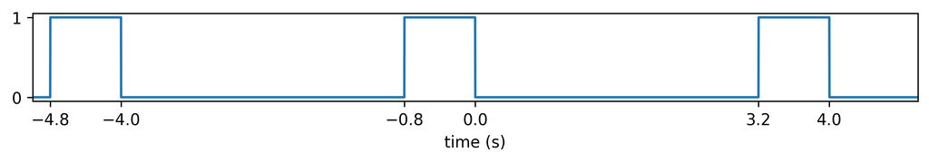

### Signal 2

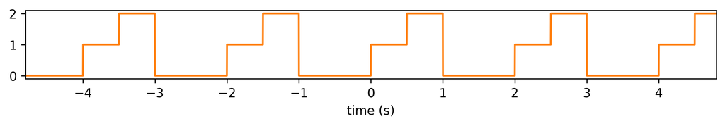

### Bonus

For bonus points, repeat the above steps for Signals 3 and 4

### Signal 3

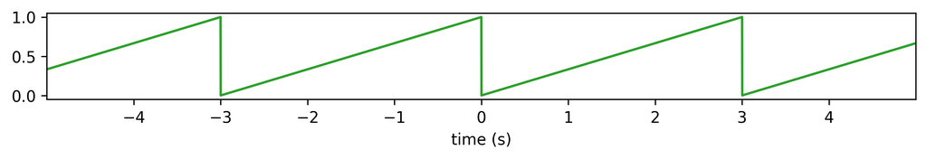

### Signal 4

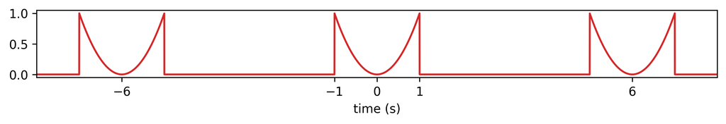

Note that the signal is *x*(*t*) = *t*<sup>2</sup> for − 1 < *t* < 1

### ECG Filtering

Last week, you built a simple RC circuit with a cutoff frequency.

This week, you will build on this by designing an RC filter to filter out the noise in the ECG signal from the file `ecg_data.txt`

To get checked off do and show the following:

- Use the buffer option in the signal generator in Scopy to load the `ecg_data.txt` file and view it.
- Use the spectrum analyzer to locate where the noise is in the signal (it will be a large peak). We will call this fnoise. It is less than 200 Hz.
- Design a filter to filter out this noise. You should include a potentiometer so you can change your cutoff frequency in real time (your cutoff should at least be adjustable to the range fnoise-50Hz to fnoise). Make sure to stay within your current limits of scopy.
- Show your results with both the spectrum analyzer and the oscilloscope.
- Be prepared to answer the questions: What cutoff frequency do you think gives the best EKG output? How did you design your circuit?